# Gallery

Fire simulation visualizations showcasing different features of Wildfires.jl.

## Directional Spread Models

Cosine blending produces wider fires while the elliptical model (Anderson, 1983) creates more realistic elongated shapes.

[figure not shown]

## Wind Direction Rose

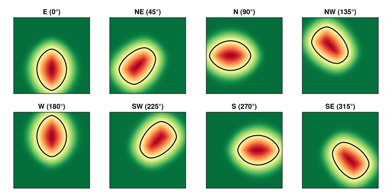

## Calm Wind

Near-zero wind produces nearly circular spread, driven primarily by the base rate of spread.

[figure not shown]

## Burnout Ring

With burnout enabled, consumed fuel stops contributing to spread. The burnout-aware colormap shows actively burning cells (yellow/red) and consumed cells (black).

[figure not shown]

## Slope Effect

Fire spreads faster uphill due to radiative pre-heating of fuels above the flame.

[figure not shown]

## Dynamic Moisture

`DynamicMoisture` models fire-induced fuel drying — radiative heat dries nearby fuel, creating a positive feedback loop that accelerates spread.

[figure not shown]

## Arrival Time Isochrones

The `t_ignite` field records when each cell ignited. White contour lines show fire front positions at equal time intervals.

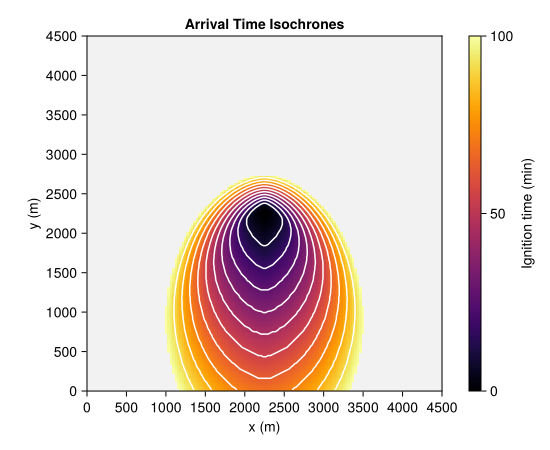

## Multiple Ignition Points

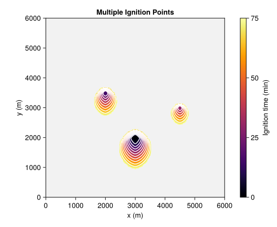

## Fuel Type Comparison

Different fuel models produce dramatically different spread rates and fire shapes under identical conditions.

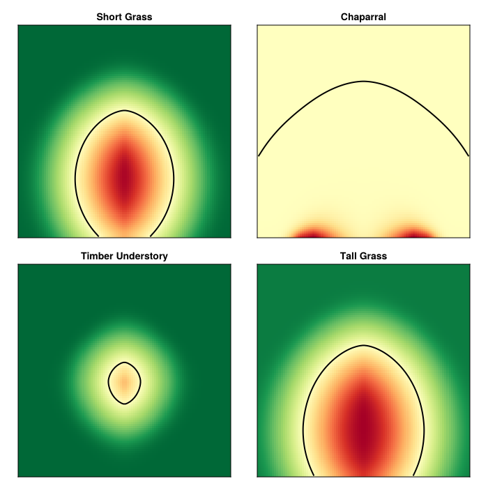

## Hero Animation

Elliptical spread with burnout on chaparral fuel over real-world terrain (Thomas Fire origin, Anlauf Canyon, CA) with wind particles — also displayed on the landing page.

[figure not shown]